# Basketball Performance Analysis

Manasa Kuchipudi

2026-09-01

# NBA Basketball Regression Analysis

## Overview

This project analyzes NBA game data from the 2017–2019 seasons to explore how different aspects of team performance are related to margin of victory (`MOV`).

The analysis uses simple and multiple linear regression to investigate relationships between basketball statistics and game outcomes. I then compare regression models and use ANOVA to determine whether shooting percentages provide statistically significant information about margin of victory.

This analysis was developed from work completed in my Applied Regression course at the University of Colorado Boulder. I reorganized the analyses into this portfolio project to demonstrate my work with R, regression modeling, statistical inference, and data visualization.

The basketball dataset contains a random sample of NBA games from the 2017–2019 seasons.

Some of the variables used in this analysis include:

- `MOV`: Margin of victory
- `X1PP`: Free-throw (one-point) shooting percentage
- `X2PP`: Two-point shooting percentage
- `X3PP`: Three-point shooting percentage
- `AST`: Assists
- `season`: NBA season
- `game_id`: Game identifier
- `team`: Team identifier

```r
bball <- read_csv("basketball.csv")

glimpse(bball)
```

```
## Rows: 999
## Columns: 10
## $ season  <dbl> 2017, 2017, 2017, 2019, 2017, 2019, 2018, 2019, 2019, 2017, 20…
## $ game_id <chr> "c7b26b9d-92dd-44cb-965f-711b0a334ee2", "cbb58bbd-fa19-4e86-87…
## $ team    <chr> "UTA", "NO", "IND", "POR", "UTA", "CLE", "ATL", "MIA", "DET", …
## $ X1PP    <dbl> 0.5769231, 0.8333333, 0.6774194, 0.6538462, 0.7647059, 0.73913…
## $ X2PP    <dbl> 0.6511628, 0.5161290, 0.6136364, 0.6400000, 0.5625000, 0.41818…
## $ X3PP    <dbl> 0.3870968, 0.3000000, 0.3846154, 0.2564103, 0.2727273, 0.45945…
## $ AST     <dbl> 24, 23, 20, 22, 11, 26, 36, 25, 23, 27, 31, 29, 35, 19, 28, 35…
## $ OREB    <dbl> 7, 2, 8, 10, 9, 16, 15, 9, 9, 5, 10, 7, 4, 18, 13, 11, 15, 9, …
## $ TO      <dbl> 15, 15, 14, 11, 13, 14, 9, 13, 13, 9, 20, 17, 16, 20, 15, 10, …
## $ MOV     <dbl> 10, -19, 4, -12, -15, 7, 1, -13, 15, 30, 13, 6, 15, 4, -6, 29,…
```

# 2. Exploratory Data Analysis

Before building regression models, I explored relationships between the quantitative variables in the dataset.

The identifying variables `season`, `game_id`, and `team` are removed from the scatterplot matrix because I am primarily interested in relationships among numerical performance statistics.

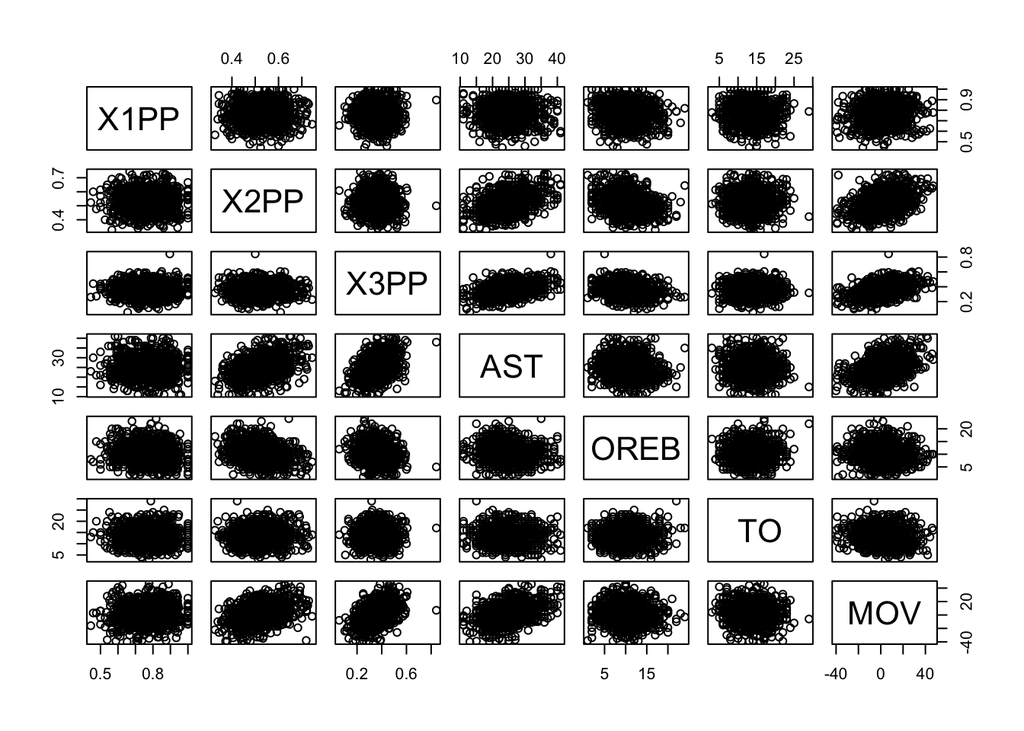

```r
bball_temp <- bball %>%
  select(-season, -game_id, -team)

pairs(bball_temp)
```

The exploratory plots suggest that two-point percentage, three-point percentage, and assists may have linear relationships with margin of victory.

These variables are therefore useful candidates for regression modeling.

# 3. Simple Linear Regression

I first examine the relationship between two-point shooting percentage (`X2PP`) and margin of victory (`MOV`).

```r
model1 <- lm(MOV ~ X2PP, data = bball)

summary(model1)
```

```
##
## Call:
## lm(formula = MOV ~ X2PP, data = bball)
##
## Residuals:
##     Min      1Q  Median      3Q     Max
## -54.870  -8.684   0.420   8.600  37.358
##
## Coefficients:
##             Estimate Std. Error t value Pr(>|t|)
## (Intercept)  -37.307      3.054  -12.22   <2e-16 ***
## X2PP          75.377      5.774   13.05   <2e-16 ***
## ---
## Signif. codes:  0 '***' 0.001 '**' 0.01 '*' 0.05 '.' 0.1 ' ' 1
##
## Residual standard error: 13.29 on 997 degrees of freedom
## Multiple R-squared:  0.146,  Adjusted R-squared:  0.1451
## F-statistic: 170.4 on 1 and 997 DF,  p-value: < 2.2e-16
```

The fitted regression model is approximately:

$$\widehat{MOV} = -37.31 + 75.38(X2PP)$$

This model explains approximately 15% of the variability in margin of victory.

The residual standard error is approximately 13 points, meaning observed margins of victory typically differ from their fitted values by roughly 13 points.

Although two-point percentage is related to margin of victory, much of the variation remains unexplained.

This suggests that additional basketball statistics may improve the model.

# 4. Multiple Linear Regression

## Adding Three-Point Percentage

Next, I add three-point shooting percentage (`X3PP`) to the model.

```r
model2 <- lm(MOV ~ X2PP + X3PP, data = bball)

summary(model2)
```

```
##
## Call:
## lm(formula = MOV ~ X2PP + X3PP, data = bball)
##
## Residuals:
##     Min      1Q  Median      3Q     Max
## -47.509  -8.515   0.009   8.019  34.417
##
## Coefficients:
##             Estimate Std. Error t value Pr(>|t|)
## (Intercept)  -61.665      3.104  -19.86   <2e-16 ***
## X2PP          75.575      5.138   14.71   <2e-16 ***
## X3PP          67.419      4.156   16.22   <2e-16 ***
## ---
## Signif. codes:  0 '***' 0.001 '**' 0.01 '*' 0.05 '.' 0.1 ' ' 1
##
## Residual standard error: 11.83 on 996 degrees of freedom
## Multiple R-squared:  0.3245, Adjusted R-squared:  0.3231
## F-statistic: 239.2 on 2 and 996 DF,  p-value: < 2.2e-16
```

The fitted model is approximately:

$$\widehat{MOV}
=
-61.67
+
75.58(X2PP)
+
67.42(X3PP)$$

Adding three-point percentage substantially improves the model.

The model now explains approximately 32% of the variability in margin of victory, and the residual standard error decreases to approximately 12 points.

This suggests that three-point percentage provides useful information beyond two-point percentage alone.

# 5. Adding Assists

Next, I investigate whether assists provide additional explanatory power.

```r
model3 <- lm(MOV ~ X2PP + X3PP + AST, data = bball)

summary(model3)
```

```
##
## Call:
## lm(formula = MOV ~ X2PP + X3PP + AST, data = bball)
##
## Residuals:
##     Min      1Q  Median      3Q     Max
## -46.751  -8.537   0.168   8.117  36.184
##
## Coefficients:
##              Estimate Std. Error t value Pr(>|t|)
## (Intercept) -61.35970    3.09547 -19.822  < 2e-16 ***
## X2PP         67.70250    5.83042  11.612  < 2e-16 ***
## X3PP         61.20591    4.69028  13.050  < 2e-16 ***
## AST           0.24591    0.08714   2.822  0.00487 **
## ---
## Signif. codes:  0 '***' 0.001 '**' 0.01 '*' 0.05 '.' 0.1 ' ' 1
##
## Residual standard error: 11.79 on 995 degrees of freedom
## Multiple R-squared:  0.3299, Adjusted R-squared:  0.3278
## F-statistic: 163.3 on 3 and 995 DF,  p-value: < 2.2e-16
```

The fitted model is approximately:

$$\widehat{MOV}
=
-61.36
+
67.70(X2PP)
+
61.21(X3PP)
+
0.25(AST)$$

Adding assists produces relatively little additional improvement compared with the model containing only two-point and three-point percentages.

This demonstrates an important issue in multiple regression: adding another predictor does not necessarily create a meaningfully better model.

# 6. Comparing the Models

One way to compare regression models is using $R^2$.

However, ordinary $R^2$ will never decrease when another predictor is added to a regression model.

Because of this, adjusted $R^2$ is more useful when comparing models containing different numbers of predictors.

Adjusted $R^2$ penalizes unnecessary model complexity.

$$R^2_{adj}
=
1-
\frac{RSS}{TSS}
\left(
\frac{n-1}{n-1-p}
\right)$$

where:

- $RSS$ = residual sum of squares
- $TSS$ = total sum of squares
- $n$ = number of observations
- $p$ = number of predictors

I can directly compare the models in R:

```r
model_comparison <- data.frame(
  Model = c(
    "X2PP",
    "X2PP + X3PP",
    "X2PP + X3PP + AST"
  ),

  R_Squared = c(
    summary(model1)$r.squared,
    summary(model2)$r.squared,
    summary(model3)$r.squared
  ),

  Adjusted_R_Squared = c(
    summary(model1)$adj.r.squared,
    summary(model2)$adj.r.squared,
    summary(model3)$adj.r.squared
  ),

  Residual_SE = c(
    summary(model1)$sigma,
    summary(model2)$sigma,
    summary(model3)$sigma
  )
)

model_comparison
```

```
##               Model R_Squared Adjusted_R_Squared Residual_SE
## 1              X2PP 0.1459978          0.1451412    13.29211
## 2       X2PP + X3PP 0.3244930          0.3231366    11.82762
## 3 X2PP + X3PP + AST 0.3298567          0.3278362    11.78649
```

The largest improvement occurs when three-point percentage is added to the original two-point percentage model.

Adding assists produces much less improvement.

# 7. Interpreting Multiple Regression Coefficients

An important difference between simple and multiple regression is how coefficients are interpreted.

In multiple regression, the coefficient for a predictor describes its relationship with the response **while holding the other predictors constant**.

For example, in `model3`, the coefficient for two-point percentage is approximately:

$$67.70$$

Because shooting percentage is represented as a decimal, a one-percentage-point increase corresponds to:

$$0.01$$

Therefore:

$$67.70(0.01)=0.677$$

A one-percentage-point increase in two-point shooting percentage is associated with an expected increase of approximately **0.677 points in margin of victory**, holding three-point percentage and assists constant.

# 8. ANOVA: Do Shooting Percentages Matter?

The previous models suggest that shooting percentages are associated with margin of victory.

Next, I test whether free-throw percentage, two-point percentage, and three-point percentage are useful predictors when considered together.

I create a dataset containing:

- Margin of victory (`MOV`)
- Free-throw percentage (`X1PP`)
- Two-point percentage (`X2PP`)
- Three-point percentage (`X3PP`)

```r
nba <- bball %>%
  select(MOV, X1PP, X2PP, X3PP) %>%
  na.omit()
```

The regression model is:

$$MOV
=
\beta_0
+
\beta_1X1PP
+
\beta_2X2PP
+
\beta_3X3PP
+
\epsilon$$

# 9. ANOVA Hypotheses

The overall ANOVA test asks whether the predictors collectively provide useful information about margin of victory.

The null hypothesis is:

$$H_0:
\beta_1
=
\beta_2
=
\beta_3
=
0$$

The alternative hypothesis is:

$$H_A:
\text{At least one } \beta_j \neq 0$$

I use a significance level of:

$$\alpha = 0.01$$

If the null hypothesis were true, none of the three shooting percentages would provide useful linear information about margin of victory.

# 10. Understanding the F-Statistic

ANOVA compares variation explained by the regression model with variation that remains unexplained.

The residual variation is measured using the mean squared error:

$$MSE
=
\frac{RSS}{n-1-p}$$

The variation explained by the predictors is measured using:

$$MSG
=
\frac{TSS-RSS}{p}$$

The F-statistic is:

$$F
=
\frac{MSG}{MSE}$$

A large F-statistic indicates that the regression model explains substantially more variation than would be expected from an intercept-only model.

# 11. Calculating the F-Statistic

First, I fit the multiple regression model.

```r
model <- lm(MOV ~ ., data = nba)

summary(model)
```

```
##
## Call:
## lm(formula = MOV ~ ., data = nba)
##
## Residuals:
##     Min      1Q  Median      3Q     Max
## -48.663  -8.243   0.188   8.116  33.312
##
## Coefficients:
##             Estimate Std. Error t value Pr(>|t|)
## (Intercept)  -69.491      4.212 -16.499  < 2e-16 ***
## X1PP          10.168      3.713   2.739  0.00628 **
## X2PP          75.845      5.122  14.808  < 2e-16 ***
## X3PP          66.975      4.145  16.156  < 2e-16 ***
## ---
## Signif. codes:  0 '***' 0.001 '**' 0.01 '*' 0.05 '.' 0.1 ' ' 1
##
## Residual standard error: 11.79 on 995 degrees of freedom
## Multiple R-squared:  0.3295, Adjusted R-squared:  0.3275
## F-statistic:   163 on 3 and 995 DF,  p-value: < 2.2e-16
```

Next, I calculate the fitted values and sums of squares.

```r
nba_mod <- nba %>%
  mutate(
    MOV_bar = mean(MOV),
    MOV_hat = predict(model, newdata = nba)
  ) %>%
  summarize(
    TSS = sum((MOV - MOV_bar)^2),
    RSS = sum((MOV - MOV_hat)^2)
  )

nba_mod
```

```
## # A tibble: 1 × 2
##       TSS     RSS
##     <dbl>   <dbl>
## 1 206264. 138291.
```

Now I calculate the F-statistic.

```r
n <- nrow(nba)
p <- 3

f_stat <- as.numeric(
  ((nba_mod$TSS - nba_mod$RSS) / p) /
  (nba_mod$RSS / (n - 1 - p))
)

f_stat
```

```
## [1] 163.0233
```

The observed F-statistic is approximately **163**.

This is a very large F-statistic, suggesting that the model explains substantially more variation in margin of victory than an intercept-only model.

# 12. Randomization-Based ANOVA

I can also examine the ANOVA test using randomization.

Under the null hypothesis, shooting percentages should not have a meaningful relationship with margin of victory.

Therefore, I can randomly shuffle `MOV` to break the relationship between margin of victory and the predictors.

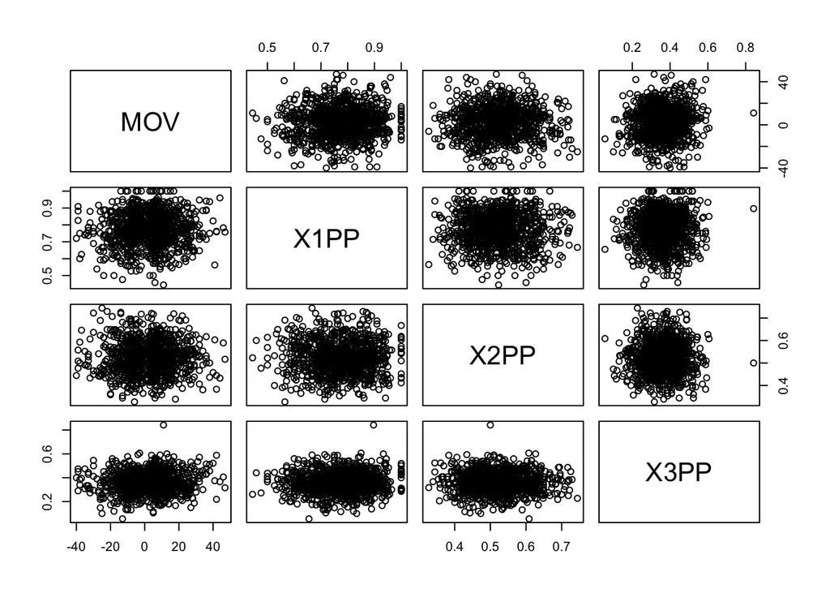

```r
set.seed(1)

nba_null <- nba %>%
  mutate(
    MOV = sample(MOV, size = n(), replace = FALSE)
  )

pairs(nba_null)
```

The relationships visible in the original data should largely disappear after the response variable is randomly shuffled.

# 13. Creating a Null Distribution

I repeat the randomization process 1,000 times.

For each randomized dataset, I:

1. Shuffle margin of victory.
2. Fit the regression model.
3. Calculate an F-statistic.
4. Store the resulting statistic.

```r
results <- data.frame(
  fstat = rep(NA, 1000)
)

for (i in 1:1000) {

  set.seed(i)

  nba_null <- nba %>%
    mutate(
      MOV = sample(MOV, size = n(), replace = FALSE)
    )

  model_null <- lm(MOV ~ ., data = nba_null)

  nba_pred <- nba_null %>%
    mutate(
      MOV_bar = mean(MOV),
      MOV_hat = predict(model_null, newdata = nba_null)
    ) %>%
    summarize(
      TSS = sum((MOV - MOV_bar)^2),
      RSS = sum((MOV - MOV_hat)^2)
    )

  n_null <- nrow(nba_null)

  results$fstat[i] <- as.numeric(
    ((nba_pred$TSS - nba_pred$RSS) / 3) /
    (nba_pred$RSS / (n_null - 1 - 3))
  )
}
```

# 14. Visualizing the Randomization Distribution

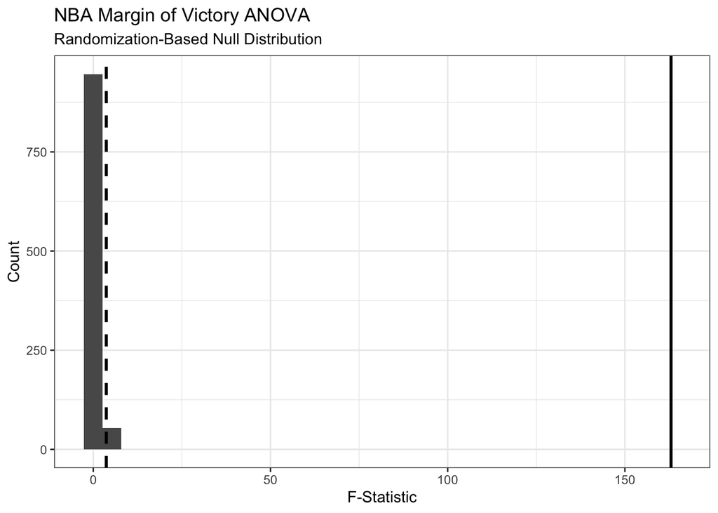

```r
ggplot(data = results, aes(x = fstat)) +
  geom_histogram(bins = 32) +
  geom_vline(
    xintercept = quantile(results$fstat, probs = 0.99),
    linewidth = 1,
    linetype = "dashed"
  ) +
  geom_vline(
    xintercept = f_stat,
    linewidth = 1
  ) +
  labs(
    title = "NBA Margin of Victory ANOVA",
    subtitle = "Randomization-Based Null Distribution",
    x = "F-Statistic",
    y = "Count"
  ) +
  theme_bw()
```

The F-statistics produced under the null hypothesis are concentrated near much smaller values than the observed statistic.

The 1% rejection threshold from the randomization distribution is approximately **3.67**, while the observed F-statistic is approximately **163**.

Because the observed statistic is far beyond the rejection threshold, I reject the null hypothesis.

There is sufficient evidence that **at least one of the shooting-percentage predictors is associated with margin of victory**.

# 15. Theoretical F-Distribution

Instead of generating a randomization distribution, the test can also be performed using the theoretical F-distribution.

The numerator degrees of freedom are:

$$df_1 = p = 3$$

The denominator degrees of freedom are:

$$df_2 = n-1-p$$

```r
set.seed(303)

fdist <- data.frame(
  fstat = rf(
    n = 1000,
    df1 = 3,
    df2 = nrow(nba) - 1 - 3
  )
)
```

I can visualize the theoretical distribution and compare the observed statistic with the rejection threshold.

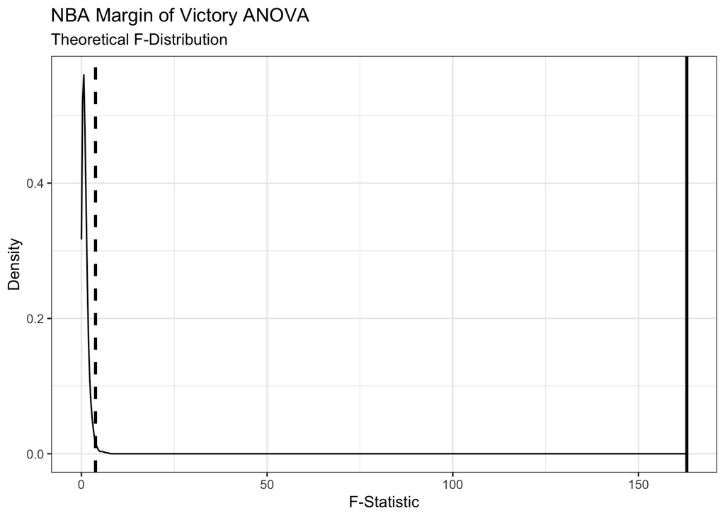

```r
ggplot(data = fdist, aes(x = fstat)) +
  geom_density(adjust = 2) +
  geom_vline(
    xintercept = qf(
      p = 0.01,
      df1 = 3,
      df2 = nrow(nba) - 1 - 3,
      lower.tail = FALSE
    ),
    linewidth = 1,
    linetype = "dashed"
  ) +
  geom_vline(
    xintercept = f_stat,
    linewidth = 1
  ) +
  labs(
    title = "NBA Margin of Victory ANOVA",
    subtitle = "Theoretical F-Distribution",
    x = "F-Statistic",
    y = "Density"
  ) +
  theme_bw()
```

The observed F-statistic falls far into the upper tail of the theoretical F-distribution.

This agrees with the randomization-based analysis and provides strong evidence against the null hypothesis.

# 16. Testing Individual Predictors

The overall ANOVA tells us that at least one shooting-percentage predictor is useful.

However, it does not tell us which individual predictors are statistically significant.

For an individual predictor, the hypotheses are:

$$H_0:
\beta_j = 0$$

versus

$$H_A:
\beta_j \neq 0$$

These individual coefficient tests use a t-statistic rather than an F-statistic.

The test statistic has the form:

$$t
=
\frac{\hat{\beta}_j - 0}
{SE(\hat{\beta}_j)}$$

# 17. Free-Throw Percentage

For free-throw percentage, the test statistic from the fitted model is approximately:

$$t = 2.739$$

I can calculate the two-sided p-value using R.

```r
df_resid <- nrow(nba) - 1 - 3

2 * pt(
  q = 2.739,
  df = df_resid,
  lower.tail = FALSE
)
```

```
## [1] 0.006272762
```

Because the resulting p-value is below the significance level of 0.01, I reject the null hypothesis for the free-throw percentage coefficient.

After controlling for two-point and three-point shooting percentages, **free-throw percentage remains significantly associated with margin of victory**.

# 18. Visualizing the t-Distribution

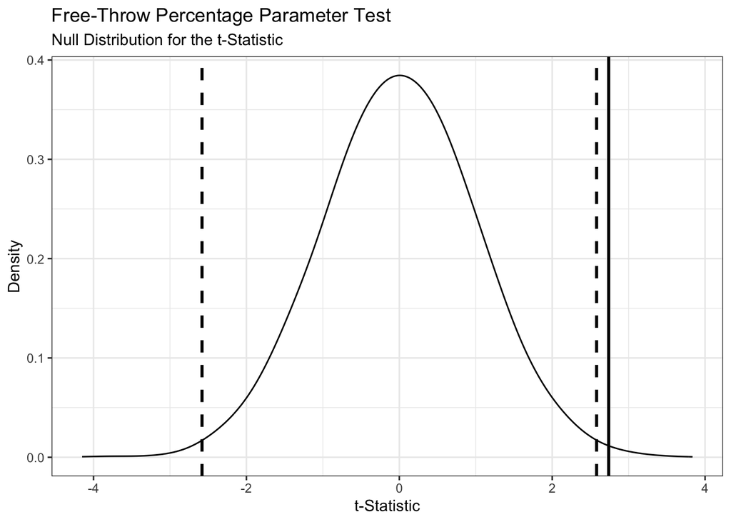

```r
set.seed(303)

tdist <- data.frame(
  tstat = rt(
    n = 10000,
    df = df_resid
  )
)

ggplot(data = tdist, aes(x = tstat)) +
  geom_density(adjust = 2) +

  geom_vline(
    xintercept = qt(
      p = 0.005,
      df = df_resid,
      lower.tail = TRUE
    ),
    linewidth = 1,
    linetype = "dashed"
  ) +

  geom_vline(
    xintercept = qt(
      p = 0.005,
      df = df_resid,
      lower.tail = FALSE
    ),
    linewidth = 1,
    linetype = "dashed"
  ) +

  geom_vline(
    xintercept = 2.739,
    linewidth = 1
  ) +

  labs(
    title = "Free-Throw Percentage Parameter Test",
    subtitle = "Null Distribution for the t-Statistic",
    x = "t-Statistic",
    y = "Density"
  ) +

  theme_bw()
```

# 19. Key Findings

This analysis demonstrates several important concepts in applied regression.

### Two-point shooting percentage is related to margin of victory

The simple regression model shows a relationship between two-point shooting percentage and margin of victory, although this predictor alone explains only part of the variation in game outcomes.

### Three-point percentage adds useful information

Adding three-point percentage substantially improves the model compared with using two-point percentage alone.

### Additional predictors do not automatically improve a model

Adding assists produces relatively little improvement compared with the two-predictor model.

This demonstrates why adjusted $R^2$ is useful when comparing regression models with different numbers of predictors.

### Shooting percentages collectively provide useful information

The ANOVA F-test strongly rejects the hypothesis that all three shooting-percentage coefficients are zero.

This provides evidence that at least one shooting-percentage variable is associated with margin of victory.

### Multiple regression coefficients require conditional interpretation

Each coefficient represents the expected change in margin of victory associated with that predictor **while holding the other predictors in the model constant**.

# 20. Conclusion

This project used NBA basketball data to examine relationships between team performance statistics and margin of victory.

Beginning with simple linear regression, I expanded the analysis to multiple regression and compared models using measures including $R^2$, adjusted $R^2$, and residual standard error.

I then used ANOVA to test whether shooting percentages collectively provide statistically meaningful information about margin of victory. Both randomization-based inference and the theoretical F-distribution produced strong evidence against the null hypothesis.

Overall, this analysis demonstrates how regression can move beyond identifying correlations to evaluating and interpreting the statistical contribution of multiple predictors.

# Skills Demonstrated

- R
- R Markdown
- `tidyverse`
- `ggplot2`
- Exploratory data analysis
- Data visualization
- Simple linear regression
- Multiple linear regression
- Model comparison
- $R^2$ and adjusted $R^2$
- ANOVA
- F-tests
- Randomization-based inference
- Hypothesis testing
- Statistical interpretation